# Practical Session PCA

Sebastian Sternberg

17 November 2017

PCA Practical Session - Learn how to do PCA in R replicating the USArrest Data example - Apply PCA to Immoscout data set - Apply it to supervised learning problems from yesterday

Goal: - Learn how to implementing PCA in R - See how PCA can help for both dimension reduction and data inspection - See how PCA can improve the computational time of supervised learning methods

# PCA application on USArrest data

```r
rm(list = ls()) #removes everything in the workspace
```

Have a look at the data set

```r
data("USArrests")
head(USArrests)
```

```
##            Murder Assault UrbanPop Rape
## Alabama      13.2     236       58 21.2
## Alaska       10.0     263       48 44.5
## Arizona       8.1     294       80 31.0
## Arkansas      8.8     190       50 19.5
## California    9.0     276       91 40.6
## Colorado      7.9     204       78 38.7
```

A first look at the data: a matrix of scatterplots

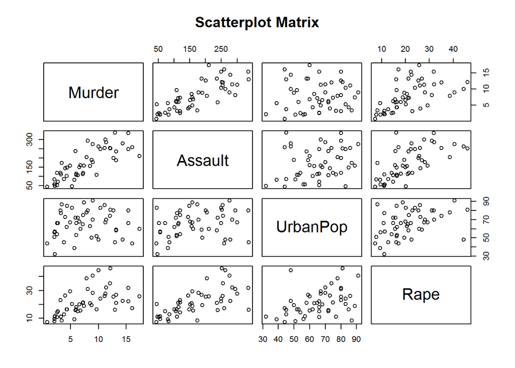

```r
pairs(USArrests, main = "Scatterplot Matrix")
```

Notice that in this simple example, we already see through eyeballing that some variables are correlated. In the big data context, eyeballing is no longer feasable.

PCA in R is done using the prcomp() function

```r
?prcomp #looking at the help function
```

```
## starting httpd help server ... done
```

prcomp() returns an object that includes everything we need for the PCA. This includes the loadings and scores, as well as the explained variance which we use later to judge how good PCA worked.

```r
pca.usa <- prcomp(x = USArrests,
                  scale. = TRUE)
```

The pca.usa object contains the results of the PCA.

```r
pca.usa
```

```
## Standard deviations:
## [1] 1.5748783 0.9948694 0.5971291 0.4164494
##
## Rotation:
##                 PC1        PC2        PC3         PC4
## Murder   -0.5358995  0.4181809 -0.3412327  0.64922780
## Assault  -0.5831836  0.1879856 -0.2681484 -0.74340748
## UrbanPop -0.2781909 -0.8728062 -0.3780158  0.13387773
## Rape     -0.5434321 -0.1673186  0.8177779  0.08902432
```

By default, it shows the new dimensions in the columns for all the independent variables in the rows. Of course we can also look at the loadings and the individuals scores for each state.

```r
pca.usa$rotation #contains the loadings
```

```
##                 PC1        PC2        PC3         PC4
## Murder   -0.5358995  0.4181809 -0.3412327  0.64922780
## Assault  -0.5831836  0.1879856 -0.2681484 -0.74340748
## UrbanPop -0.2781909 -0.8728062 -0.3780158  0.13387773
## Rape     -0.5434321 -0.1673186  0.8177779  0.08902432
```

```r
pca.usa$x       # contains the scores
```

```
##                        PC1         PC2         PC3          PC4
## Alabama        -0.97566045  1.12200121 -0.43980366  0.154696581
## Alaska         -1.93053788  1.06242692  2.01950027 -0.434175454
## Arizona        -1.74544285 -0.73845954  0.05423025 -0.826264240
## Arkansas        0.13999894  1.10854226  0.11342217 -0.180973554
## California     -2.49861285 -1.52742672  0.59254100 -0.338559240
## Colorado       -1.49934074 -0.97762966  1.08400162  0.001450164
## Connecticut     1.34499236 -1.07798362 -0.63679250 -0.117278736
## Delaware       -0.04722981 -0.32208890 -0.71141032 -0.873113315
## Florida        -2.98275967  0.03883425 -0.57103206 -0.095317042
## Georgia        -1.62280742  1.26608838 -0.33901818  1.065974459
## Hawaii          0.90348448 -1.55467609  0.05027151  0.893733198
## Idaho           1.62331903  0.20885253  0.25719021 -0.494087852
## Illinois       -1.36505197 -0.67498834 -0.67068647 -0.120794916
## Indiana         0.50038122 -0.15003926  0.22576277  0.420397595
## Iowa            2.23099579 -0.10300828  0.16291036  0.017379470
## Kansas          0.78887206 -0.26744941  0.02529648  0.204421034
## Kentucky        0.74331256  0.94880748 -0.02808429  0.663817237
## Louisiana      -1.54909076  0.86230011 -0.77560598  0.450157791
## Maine           2.37274014  0.37260865 -0.06502225 -0.327138529
## Maryland       -1.74564663  0.42335704 -0.15566968 -0.553450589
## Massachusetts   0.48128007 -1.45967706 -0.60337172 -0.177793902
## Michigan       -2.08725025 -0.15383500  0.38100046  0.101343128
## Minnesota       1.67566951 -0.62590670  0.15153200  0.066640316
## Mississippi    -0.98647919  2.36973712 -0.73336290  0.213342049
## Missouri       -0.68978426 -0.26070794  0.37365033  0.223554811
## Montana         1.17353751  0.53147851  0.24440796  0.122498555
## Nebraska        1.25291625 -0.19200440  0.17380930  0.015733156
## Nevada         -2.84550542 -0.76780502  1.15168793  0.311354436
## New Hampshire   2.35995585 -0.01790055  0.03648498 -0.032804291
## New Jersey     -0.17974128 -1.43493745 -0.75677041  0.240936580
## New Mexico     -1.96012351  0.14141308  0.18184598 -0.336121113
## New York       -1.66566662 -0.81491072 -0.63661186 -0.013348844
## North Carolina -1.11208808  2.20561081 -0.85489245 -0.944789648
## North Dakota    2.96215223  0.59309738  0.29824930 -0.251434626
## Ohio            0.22369436 -0.73477837 -0.03082616  0.469152817
## Oklahoma        0.30864928 -0.28496113 -0.01515592  0.010228476
## Oregon         -0.05852787 -0.53596999  0.93038718 -0.235390872
## Pennsylvania    0.87948680 -0.56536050 -0.39660218  0.355452378
## Rhode Island    0.85509072 -1.47698328 -1.35617705 -0.607402746
## South Carolina -1.30744986  1.91397297 -0.29751723 -0.130145378
## South Dakota    1.96779669  0.81506822  0.38538073 -0.108470512
## Tennessee      -0.98969377  0.85160534  0.18619262  0.646302674
## Texas          -1.34151838 -0.40833518 -0.48712332  0.636731051
## Utah            0.54503180 -1.45671524  0.29077592 -0.081486749
## Vermont         2.77325613  1.38819435  0.83280797 -0.143433697
## Virginia        0.09536670  0.19772785  0.01159482  0.209246429
## Washington      0.21472339 -0.96037394  0.61859067 -0.218628161
## West Virginia   2.08739306  1.41052627  0.10372163  0.130583080
## Wisconsin       2.05881199 -0.60512507 -0.13746933  0.182253407
## Wyoming         0.62310061  0.31778662 -0.23824049 -0.164976866
```

Let’s replicate the biplot from the presentation. Again, the biplot is based on the first two principal components and contains information about the scores and the loadings (magnitudes) of the new dimensions.

First we produce a simple scatterplot of the first two principle components.

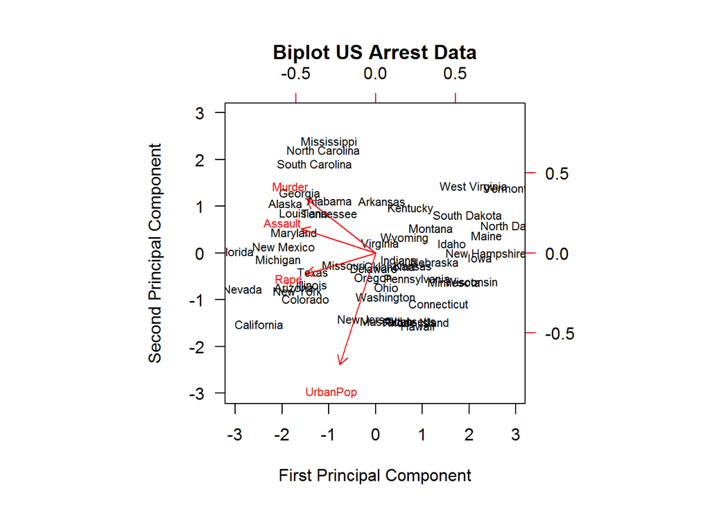

```r
biplot(pca.usa,
       scale=0,
       cex=.7,
       main = "Biplot US Arrest Data",
       xlab = "First Principal Component",
       ylab = "Second Principal Component",
       las = 1)
```

```r
pca.usa$rotation <- -pca.usa$rotation #multiplying the original rotation (loadings) times -1
pca.usa$x <- -pca.usa$x               #multiplying the original scores times -1
```

Now we can replicate the biplot from the presentation. In R, this is done using the biplot() function.

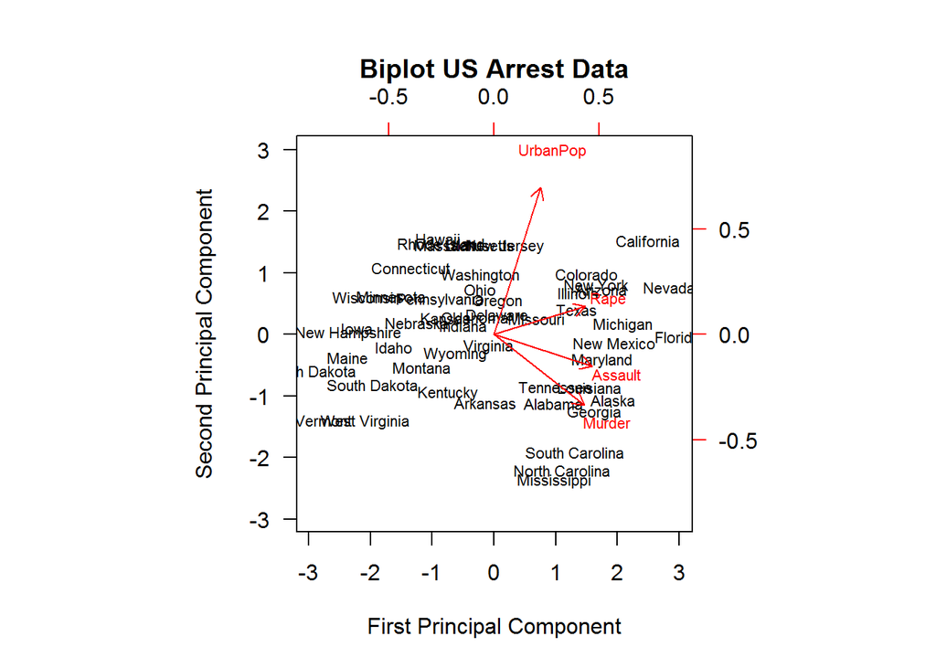

```r
biplot(pca.usa,
       scale=0,
       cex=.7,
       main = "Biplot US Arrest Data",
       xlab = "First Principal Component",
       ylab = "Second Principal Component",
       las = 1)
```

**Interpretation:** A biplot always plots the first two principle components of a data set.

- The black state names represent the scores of the states for the first two principal components (like a coordinate system)
- The red arrows indicate the first two principal component loading vectors (and therefore, the magnitude)
- For example, the loading for Rape on the first component is 0.54, and it loading on the second principal component 0.17 (the word Rape is centered at the point (0.54, 0.17)).
- The first loading vector places approximately equal weight on Assault, Murder ,and Rape, less weight on UrbanPop
- This component corresponds to the overall rates of serious crime
- Second loading vector places most of its weight on UrbanPop and much less weight on the other three features
- This component corresponds to the level of urbanization of the state
- Crime-related variables are located close to each other; UrbanPop is distant
- Crime-related variables are correlated with each other
- States with high murder rates tend to have high assault and rape rates; UrbanPop variable is less correlated with the other three

The importance of scaling:

Scaling is very important to ensure that the variables used in the PCA are comparable. Not scaling variables results in a highly missleading PCA output.

We replicate the example from the presentation.

```r
pca.usa.unscaled <- prcomp(USArrests, scale. = F) #this is an unscaled PCA of the usArrest data
```

Let’s compare the two PCA outputs in two biplots

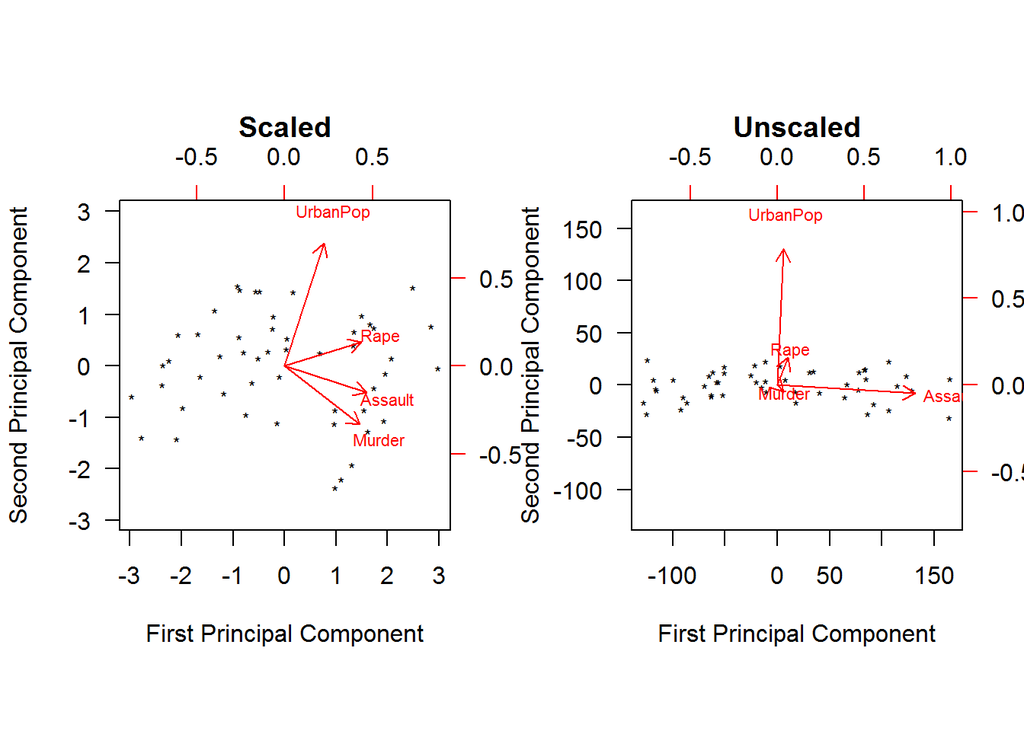

```r
par(mfrow = c(1,2))#set the graphic margins so that we can plot side by side

biplot(pca.usa,
       scale=0,
       cex=.7,
       main = "Scaled",
       xlab = "First Principal Component",
       ylab = "Second Principal Component",
       las = 1,
       xlabs = rep("*", nrow(USArrests)) #the labels should not be displayed so that we see more
)

biplot(pca.usa.unscaled,
       scale=0,
       cex=.7,
       main = "Unscaled",
       xlab = "First Principal Component",
       ylab = "Second Principal Component",
       las = 1,
       xlabs = rep("*", nrow(USArrests))#the labels should not be displayed so that we see more
)
```

```r
par(mfrow = c(1,1)) #set the graphic parameters back
```

Why makes scaling such a difference? Variables are measured in different units; Murder, Rape,and Assault are reported as the number of occurrences per 100,000 people, and UrbanPop is the percentage of the state’s population that lives in an urban area. These four variables have variance 18.97, 87.73, 6945.16,and 209.5, respectively. Consequently, if we perform PCA on the unscaled variables, then the first principal component loading vector will have a very large loading for Assault, since that variable has by far the highest variance. Because it is undesirable for the principal components obtained to depend on an arbitrary choice of scaling, we typically scale each variable to have standard deviation one before we perform PCA.

Scaling and not scaling results in different loadings and scores for the PCAs

```r
#the loadings are different:
pca.usa.unscaled$rotation
```

```
##                 PC1         PC2         PC3         PC4
## Murder   0.04170432 -0.04482166  0.07989066 -0.99492173
## Assault  0.99522128 -0.05876003 -0.06756974  0.03893830
## UrbanPop 0.04633575  0.97685748 -0.20054629 -0.05816914
## Rape     0.07515550  0.20071807  0.97408059  0.07232502
```

```r
pca.usa$rotation
```

```
##                PC1        PC2        PC3         PC4
## Murder   0.5358995 -0.4181809  0.3412327 -0.64922780
## Assault  0.5831836 -0.1879856  0.2681484  0.74340748
## UrbanPop 0.2781909  0.8728062  0.3780158 -0.13387773
## Rape     0.5434321  0.1673186 -0.8177779 -0.08902432
```

```r
#and the scores differ, too:

pca.usa.unscaled$x
```

```
##                        PC1         PC2          PC3        PC4
## Alabama          64.802164 -11.4480074  -2.49493284 -2.4079009
## Alaska           92.827450 -17.9829427  20.12657487  4.0940470
## Arizona         124.068216   8.8304030  -1.68744836  4.3536852
## Arkansas         18.340035 -16.7039114   0.21018936  0.5209936
## California      107.422953  22.5200698   6.74587299  2.8118259
## Colorado         34.975986  13.7195840  12.27936280  1.7214637
## Connecticut     -60.887282  12.9325302  -8.42065719  0.6999023
## Delaware         66.731025   1.3537978 -11.28095735  3.7279812
## Florida         165.244370   6.2746901  -2.99793315 -1.2476807
## Georgia          40.535177  -7.2902396   3.60952946 -7.3436728
## Hawaii         -123.536106  24.2912079   3.72444284 -3.4728494
## Idaho           -51.797002  -9.4691910  -1.52006356  3.3478283
## Illinois         78.992097  12.8970605  -5.88326477 -0.3676407
## Indiana         -57.550961   2.8462647   3.73816049 -1.6494302
## Iowa           -115.586790  -3.3421305  -0.65402935  0.8694960
## Kansas          -55.789694   3.1572339   0.38436416 -0.6527917
## Kentucky        -62.383181 -10.6732715   2.23708903 -3.8762164
## Louisiana        78.277631  -4.2949175  -3.82786965 -4.4835590
## Maine           -89.261044 -11.4878272  -4.69240562  2.1161995
## Maryland        129.330136  -5.0070315  -2.34717282  1.9283242
## Massachusetts   -21.266283  19.4501790  -7.50714835  1.0348189
## Michigan         85.451527   5.9045567   6.46434210 -0.4990479
## Minnesota       -98.954816   5.2096006   0.00657376  0.7318957
## Mississippi      86.856358 -27.4284196  -5.00343624 -3.8797577
## Missouri          7.986289   5.2756414   5.50057972 -0.6794055
## Montana         -62.483635  -9.5105021   1.83835536 -0.2459426
## Nebraska        -69.096544  -0.2111959   0.46802086  0.6565664
## Nevada           83.613578  15.1021839  15.88869482 -0.3341962
## New Hampshire  -114.777355  -4.7345584  -2.28238693  0.9359106
## New Jersey      -10.815725  23.1373389  -6.31015739 -1.6124273
## New Mexico      114.868163  -0.3364531   2.26126996  1.3812478
## New York         84.294231  15.9239655  -4.72125960 -0.8920194
## North Carolina  164.325514 -31.0966153 -11.69616350  2.1111927
## North Dakota   -127.495597 -16.1350394  -1.31182982  2.3009639
## Ohio            -50.086822  12.2793244   1.65733077 -2.0291157
## Oklahoma        -19.693723   3.3701310  -0.45314329  0.1803457
## Oregon          -11.150240   3.8660682   8.12998050  2.9140109
## Pennsylvania    -64.689142   8.9115466  -3.20646858 -1.8749353
## Rhode Island      3.063973  18.3739704 -17.47001970  2.3082597
## South Carolina  107.281069 -23.5361159  -2.03279501 -1.2517463
## South Dakota    -86.106720 -16.5978586   1.31437998  1.2522874
## Tennessee        17.506264  -6.5065756   6.10012753 -3.9228558
## Texas            31.291122  12.9849566  -0.39340922 -4.2420040
## Utah            -49.913397  17.6484577   1.78816852  1.8677052
## Vermont        -124.714469 -27.3135591   4.80277765  2.0049857
## Virginia        -14.817448  -1.7526150   1.04538813 -1.1738408
## Washington      -25.075839   9.9679669   4.78112764  2.6910819
## West Virginia   -91.544647 -22.9528778  -0.40198344 -0.7368781
## Wisconsin      -118.176328   5.5075792  -2.71132077 -0.2049724
## Wyoming         -10.434539  -5.9244529  -3.79444682  0.5178674
```

```r
pca.usa$x
```

```
##                        PC1         PC2         PC3          PC4
## Alabama         0.97566045 -1.12200121  0.43980366 -0.154696581
## Alaska          1.93053788 -1.06242692 -2.01950027  0.434175454
## Arizona         1.74544285  0.73845954 -0.05423025  0.826264240
## Arkansas       -0.13999894 -1.10854226 -0.11342217  0.180973554
## California      2.49861285  1.52742672 -0.59254100  0.338559240
## Colorado        1.49934074  0.97762966 -1.08400162 -0.001450164
## Connecticut    -1.34499236  1.07798362  0.63679250  0.117278736
## Delaware        0.04722981  0.32208890  0.71141032  0.873113315
## Florida         2.98275967 -0.03883425  0.57103206  0.095317042
## Georgia         1.62280742 -1.26608838  0.33901818 -1.065974459
## Hawaii         -0.90348448  1.55467609 -0.05027151 -0.893733198
## Idaho          -1.62331903 -0.20885253 -0.25719021  0.494087852
## Illinois        1.36505197  0.67498834  0.67068647  0.120794916
## Indiana        -0.50038122  0.15003926 -0.22576277 -0.420397595
## Iowa           -2.23099579  0.10300828 -0.16291036 -0.017379470
## Kansas         -0.78887206  0.26744941 -0.02529648 -0.204421034
## Kentucky       -0.74331256 -0.94880748  0.02808429 -0.663817237
## Louisiana       1.54909076 -0.86230011  0.77560598 -0.450157791
## Maine          -2.37274014 -0.37260865  0.06502225  0.327138529
## Maryland        1.74564663 -0.42335704  0.15566968  0.553450589
## Massachusetts  -0.48128007  1.45967706  0.60337172  0.177793902
## Michigan        2.08725025  0.15383500 -0.38100046 -0.101343128
## Minnesota      -1.67566951  0.62590670 -0.15153200 -0.066640316
## Mississippi     0.98647919 -2.36973712  0.73336290 -0.213342049
## Missouri        0.68978426  0.26070794 -0.37365033 -0.223554811
## Montana        -1.17353751 -0.53147851 -0.24440796 -0.122498555
## Nebraska       -1.25291625  0.19200440 -0.17380930 -0.015733156
## Nevada          2.84550542  0.76780502 -1.15168793 -0.311354436
## New Hampshire  -2.35995585  0.01790055 -0.03648498  0.032804291
## New Jersey      0.17974128  1.43493745  0.75677041 -0.240936580
## New Mexico      1.96012351 -0.14141308 -0.18184598  0.336121113
## New York        1.66566662  0.81491072  0.63661186  0.013348844
## North Carolina  1.11208808 -2.20561081  0.85489245  0.944789648
## North Dakota   -2.96215223 -0.59309738 -0.29824930  0.251434626
## Ohio           -0.22369436  0.73477837  0.03082616 -0.469152817
## Oklahoma       -0.30864928  0.28496113  0.01515592 -0.010228476
## Oregon          0.05852787  0.53596999 -0.93038718  0.235390872
## Pennsylvania   -0.87948680  0.56536050  0.39660218 -0.355452378
## Rhode Island   -0.85509072  1.47698328  1.35617705  0.607402746
## South Carolina  1.30744986 -1.91397297  0.29751723  0.130145378
## South Dakota   -1.96779669 -0.81506822 -0.38538073  0.108470512
## Tennessee       0.98969377 -0.85160534 -0.18619262 -0.646302674
## Texas           1.34151838  0.40833518  0.48712332 -0.636731051
## Utah           -0.54503180  1.45671524 -0.29077592  0.081486749
## Vermont        -2.77325613 -1.38819435 -0.83280797  0.143433697
## Virginia       -0.09536670 -0.19772785 -0.01159482 -0.209246429
## Washington     -0.21472339  0.96037394 -0.61859067  0.218628161
## West Virginia  -2.08739306 -1.41052627 -0.10372163 -0.130583080
## Wisconsin      -2.05881199  0.60512507  0.13746933 -0.182253407
## Wyoming        -0.62310061 -0.31778662  0.23824049  0.164976866
```

By looking at the covariance matrix we can see that Assault has indeed by far the highest variance.

```r
var(USArrests) #the diagonal of this variance cov. matrix includes the variance for each variable.
```

```
##              Murder   Assault   UrbanPop      Rape
## Murder    18.970465  291.0624   4.386204  22.99141
## Assault  291.062367 6945.1657 312.275102 519.26906
## UrbanPop   4.386204  312.2751 209.518776  55.76808
## Rape      22.991412  519.2691  55.768082  87.72916
```

### Proportion of variance explained

How much of the information in a given data set is lost by projecting the observations onto the first few principal components? And how many principle compoments are required for the data reduction? We can answer these questions by looking at the proportion of variance explained (PVE) by each principle component.

- The PVE is given by the positive quantity between 0 and 1 (and by design, the sum up to 1)
- We can use the eigenvalues to calculate the PVE for each principle component (eigenvector)
- The PVE of a principle component is simply $\frac{\lambda_i}{\sum_{n}^{i= 1} \lambda_i}$

To get the PVE in R, we can simply use the summary() function:

```r
summary(pca.usa)
```

```
## Importance of components:
##                           PC1    PC2     PC3     PC4
## Standard deviation     1.5749 0.9949 0.59713 0.41645
## Proportion of Variance 0.6201 0.2474 0.08914 0.04336
## Cumulative Proportion  0.6201 0.8675 0.95664 1.00000
```

Here, we see that the first two principal components explain almost 87% of the variance in the data, and the last two principal components explain only 13% of the variance.

To have a visual representation of the PVE by principle component

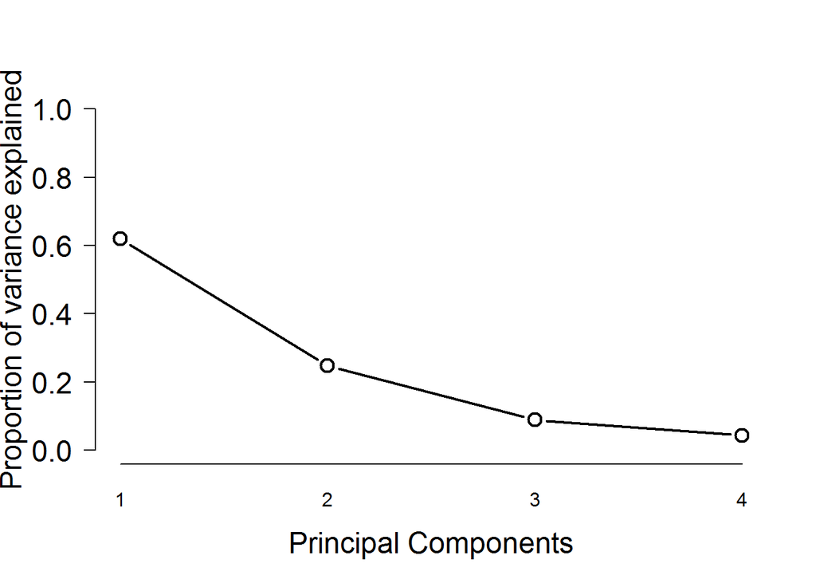

```r
#get the PVE from the pca output

pca.usa.var <- pca.usa$sdev ^ 2
pca.usa.pvar <- pca.usa.var/sum(pca.usa.var)

#This gives us exactly the variance obtained va

plot(pca.usa.pvar,
     xlab="Principal Components",
     ylab="Proportion of variance explained",
     ylim=c(0,1),
     type='b',
     xaxt='n',
     bty = "n",
     las = 1,
     cex=1.5,
     cex.axis = 1.5,
     lwd = 2,
     cex.lab=1.5)
axis(side = 1, at = 1:4, tck = 0)
```

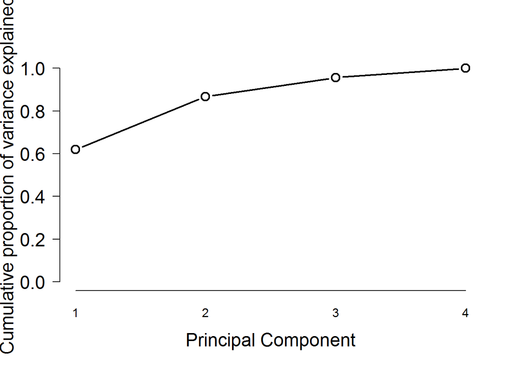

```r
#We can do the same for the cumulative proportion of variance explained
plot(cumsum(pca.usa.pvar),
     xlab="Principal Component",
     ylab="Cumulative proportion of variance explained",
     ylim=c(0,1),
     type='b',
     xaxt='n',
     bty = "n",
     las = 1,
     cex=1.5,
     cex.axis = 1.5, lwd = 2,
     cex.lab=1.5
  )
  axis(side = 1, at = 1:4, tck = 0)
```

So how many principle components should we use? The decision of how many principle components to use is often based on eyeballing using the “elbow” method. That is, we are looking for a point at which the proportion of variance explained by each subsequent principal component drops off. In our application, a fair amount of variance is explained by the first two principal components, and there is an elbow after the second component. The third principle component explains less than ten percent of the variance in the data, and the fourth principal component explains less than half that and so is essentially worthless.

### PCA applied to Immoscout data set

We want to apply PCA to the immoscout data set which was used yesterday for supervised learning. We want to achive two things: first, we want to have a better understanding of the relationship between the variables in the data set. Second, we want to extract - in the best case - a few principle components that can help to summarize the features better. PCA thus becomes a data pre-processing step.

```r
rm(list = ls())

load("FrankfurtMain.Rda")

head(fr_immo)
```

```
##                                                     address    rent     m2
## 1             Unterer Atzemer  5, Ostend, Frankfurt am Main 1357.79  79.87
## 2                             Bockenheim, Frankfurt am Main 2100.00 120.00
## 3                            Niederursel, Frankfurt am Main  950.00  60.00
## 4           Alte Mainzer G. 10, Altstadt, Frankfurt am Main  900.00  50.00
## 5             Gluckstr. 27, Nordend-West, Frankfurt am Main 1450.00 108.00
## 6 Mailänder Straße 12, Sachsenhausen-Süd, Frankfurt am Main  506.00  35.89
##   rooms      lon      lat           quarter foreigners_percentage
## 1     2 8.703810 50.11695            Ostend              27.84853
## 2     2 8.638836 50.12500        Bockenheim              28.41655
## 3     2 8.621594 50.16593       Niederursel              22.86321
## 4     2 8.679502 50.10909          Altstadt              34.82366
## 5     2 8.687626 50.12739      Nordend-West              19.62706
## 6     1 8.687840 50.09136 Sachsenhausen-Süd              20.96874
##   average_age kita_number number_doctors unemployment_rate voteshare
```

[output cut: 20 more lines]

PCA can only work with numeric data. Thus, the present data set needs to be transformed into a new data set not containing variables such as the addresses etc.

```r
fr_immo_reduced <- fr_immo[, -c(1, 5:7)] #we remove the address, the quarter, and the lon and lat
```

We could start with a scatterplot of each variable, but given that we have 16 variables in the data set, this is not really helpful.

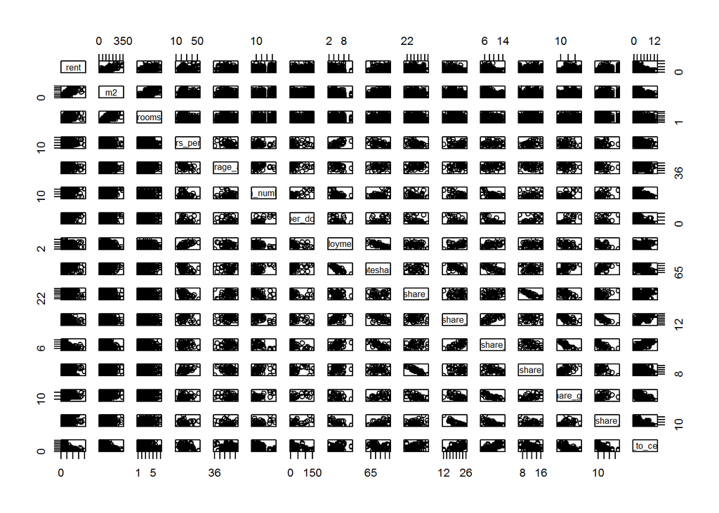

```r
pairs(fr_immo_reduced)
```

### PCA for data inspection

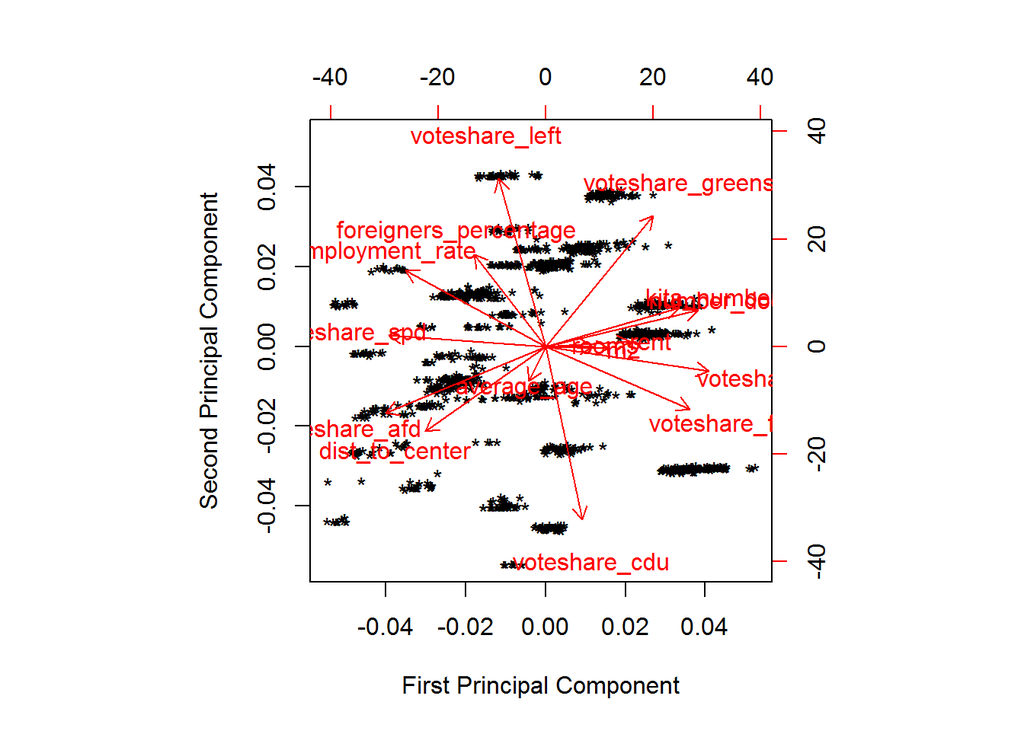

```r
pca.frmain <- prcomp(fr_immo_reduced, scale. = T)

biplot(pca.frmain,
       xlab = "First Principal Component",
       ylab = "Second Principal Component",
       xlabs = rep("*", nrow(fr_immo_reduced))#the labels should not be displayed so that we see more
)
```

A simple PCA already reveals a lot of interesting patterns which intuitively make sense: - the number of rooms, m2, and rent are highly correlated, but also with the number of kitas (day-care centers) and total numbers of doctors in a district. - the vote share of the AfD is correlated with the distance to the city center.

Of course, not scaling would make a big difference again:

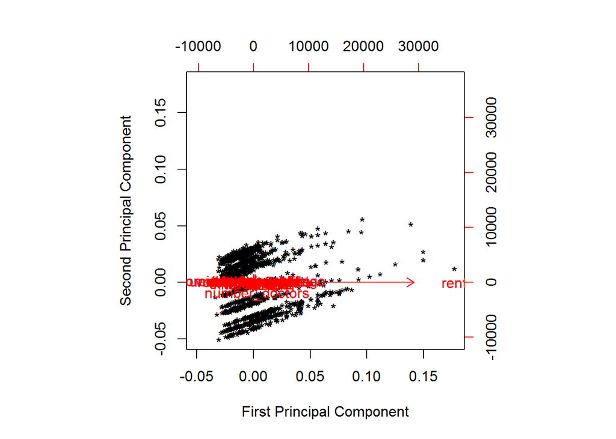

```r
pca.frmain.noscale <- prcomp(fr_immo_reduced, scale. = F)

biplot(pca.frmain.noscale,
       xlab = "First Principal Component",
       ylab = "Second Principal Component",
       xlabs = rep("*", nrow(fr_immo_reduced)) #the labels should not be displayed so that we see more
)
```

How successfull was the dimension reduction? How many principle components do we need?

```r
summary(pca.frmain)
```

```
## Importance of components:
##                           PC1    PC2    PC3     PC4     PC5     PC6
## Standard deviation     2.4943 1.8176 1.5378 1.24075 0.97441 0.83074
## Proportion of Variance 0.3888 0.2065 0.1478 0.09622 0.05934 0.04313
## Cumulative Proportion  0.3888 0.5953 0.7431 0.83935 0.89870 0.94183
##                            PC7     PC8     PC9    PC10    PC11   PC12
## Standard deviation     0.56920 0.44403 0.34222 0.29042 0.27062 0.2041
## Proportion of Variance 0.02025 0.01232 0.00732 0.00527 0.00458 0.0026
## Cumulative Proportion  0.96208 0.97440 0.98172 0.98699 0.99157 0.9942
##                           PC13    PC14    PC15    PC16
## Standard deviation     0.19672 0.16755 0.16074 0.02551
## Proportion of Variance 0.00242 0.00175 0.00161 0.00004
## Cumulative Proportion  0.99659 0.99834 0.99996 1.00000
```

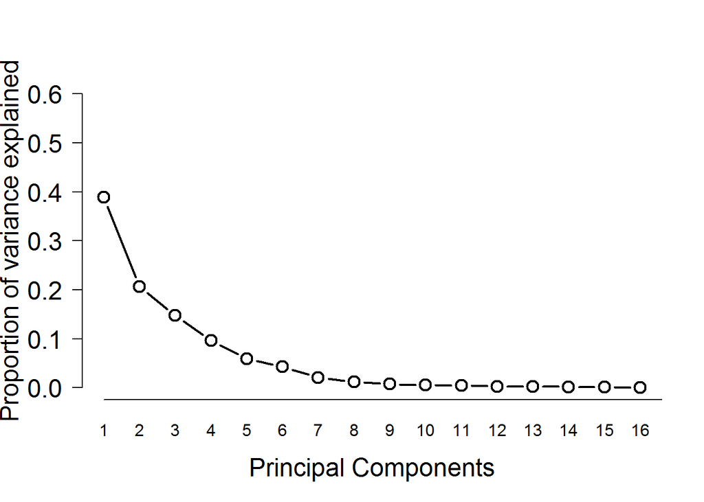

```r
#and a visual inspection using the scree plot:

pca.frmain.var <- pca.frmain$sdev ^ 2
pca.frmain.pvar <- pca.frmain.var/sum(pca.frmain.var)

#This gives us exactly the variance obtained va

plot(pca.frmain.pvar,
     xlab="Principal Components",
     ylab="Proportion of variance explained",
     ylim=c(0,0.6),
     type='b',
     xaxt='n',
     bty = "n",
     las = 1,
     cex=1.5,
     cex.axis = 1.5,
     lwd = 2,
     cex.lab=1.5)
axis(side = 1, at = 1:23, tck = 0)
```

Hence, in the following we will use the first 6 principle components to see whether we can improve the performance of yesterday’s random forest.

### PCA for dimension reduction

We first run the same random forest regression than yesterday. Using PCA to improve prediction models with respected to accuracy is debated in the literature, but can be worth it with respect to computational time in the age of Big Data. We test this using a random forest example.

```r
require(randomForest)
#Run a random forest on the first 500 observations of the whole data set
set.seed(1234)
start.time <- Sys.time()
rf_all <- randomForest(rent ~ .-address -quarter, data = fr_immo)

end.time <- Sys.time()
time.taken.all <- end.time - start.time
time.taken.all
```

```
## Time difference of 4.151007 secs
```

```r
rf_all
```

```
##
## Call:
##  randomForest(formula = rent ~ . - address - quarter, data = fr_immo)
##                Type of random forest: regression
##                      Number of trees: 500
## No. of variables tried at each split: 5
##
##           Mean of squared residuals: 98073.45
##                     % Var explained: 86.76
```

Now we use the scores of the PCA to rerun our random forest.

```r
head(pca.frmain$x)
```

```
##             PC1        PC2       PC3        PC4         PC5         PC6
## 1  3.565689e-02  1.5881576 0.8279468  0.6465685  0.86288809 -0.34313108
## 2  1.221526e+00  1.9115991 0.1208064  0.1864778 -1.28380500  0.74436466
## 3 -3.297127e+00 -1.1412419 0.6705270  1.1492562  0.09483697  0.37139437
## 4 -1.163377e+00  0.6270910 0.7999128 -0.7132916  2.14659177 -0.43067637
## 5  2.918017e+00  0.8136054 1.2179826  0.7683445 -0.08257723  0.01848716
## 6  4.676648e-05 -1.9893909 2.3379258  0.1804762  1.98949797 -0.68079531
##          PC7         PC8         PC9        PC10        PC11       PC12
## 1  0.4075416 -0.02024312  0.19781260 -0.06821840  0.00704838  0.0368857
## 2  1.2573143  0.51805181 -0.19984385 -0.41484081 -0.06576396 -0.1440390
## 3  0.4357826  0.15193491 -0.17730244  0.04119218  0.01726428 -0.3054294
## 4 -0.2336267  0.15763686  0.14160112  0.13356049 -0.43059718  0.1894604
## 5  0.5221117 -0.42148084 -0.03275716 -0.51927878  0.44765490  0.2331089
## 6  0.1486811  0.41421584  0.07390068 -0.19745383 -0.21319915 -0.2549489
##         PC13         PC14        PC15         PC16
## 1 -0.1405685  0.183793780 -0.01630106  0.005860756
## 2 -0.1257398  0.083012038  0.12637504  0.001190749
## 3 -0.2582935 -0.112062011 -0.34409177 -0.051708785
## 4 -0.0566627  0.024435946  0.33455221  0.058485118
## 5  0.1569573 -0.097521668  0.13469877  0.001317969
## 6 -0.1384796  0.001799265  0.08706396 -0.017094161
```

```r
#create new data set only including the first 6 principle components and the outcome variable
fr_main_pcascores <- as.data.frame(pca.frmain$x[, 1:6])
fr_main_pcascores$rent <- fr_immo_reduced$rent

#Run the model only including pca scores
set.seed(1234)

start.time <- Sys.time()

rf.pca <- randomForest(rent ~ ., data =fr_main_pcascores )

end.time <- Sys.time()
time.taken.pca <- end.time - start.time
time.taken.pca
```

```
## Time difference of 3.212005 secs
```

```r
rf.pca #faster + more accurate!
```

```
##
## Call:
##  randomForest(formula = rent ~ ., data = fr_main_pcascores)
##                Type of random forest: regression
##                      Number of trees: 500
## No. of variables tried at each split: 2
##
##           Mean of squared residuals: 36504.16
##                     % Var explained: 95.07
```